# Analysis: Mutant Fitness Across Environments

Ziang Zhang

This page summarizes the [MPCurver 0.3.4 fitness analysis](https://aguerozz.github.io/MPCurver/articles/fitness.html). The figures and numerical results come from that vignette.

## Data and question

The analysis contains 421 mutants measured in 45 environments. Each mutant has a fitness value and a reported measurement error in each environment. Rows are mutants, and features are environments. The question is whether one latent mutant ordering explains the variation across all environments or whether groups of environments follow different orderings.

## One ordering

The vignette starts with a single-ordering CAVI model using Isomap initialization, $K=50$ grid positions, and an RW2 trajectory prior. It then refits with a stronger smoothness prior using `lambda_sd_prior_rate = 1e4`. Comparing the inferred mutant positions helps assess whether smoothing changes the ordering or mainly the fitted curves (Figure 1).

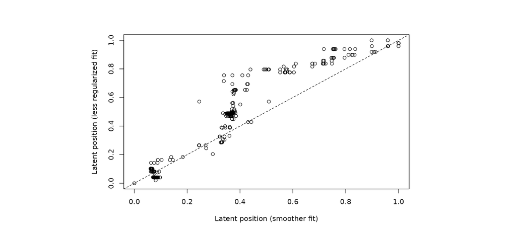

Figure 1. Comparison of inferred mutant positions under two smoothness settings, reproduced from the MPCurver 0.3.4 fitness vignette.

The two fitted mutant positions have Pearson correlation **0.952**. The stronger prior produces smoother example trajectories in the full vignette while retaining a similar mutant ordering.

## Two orderings and environment groups

The vignette next fits a structural CAVI model with `intrinsic_dim = 2`. Each environment receives probabilities of following ordering A or B, and its trajectory is estimated conditional on the assignment. Figure 2 shows both conditional trajectories for one environment and its assignment probabilities in the panel titles.

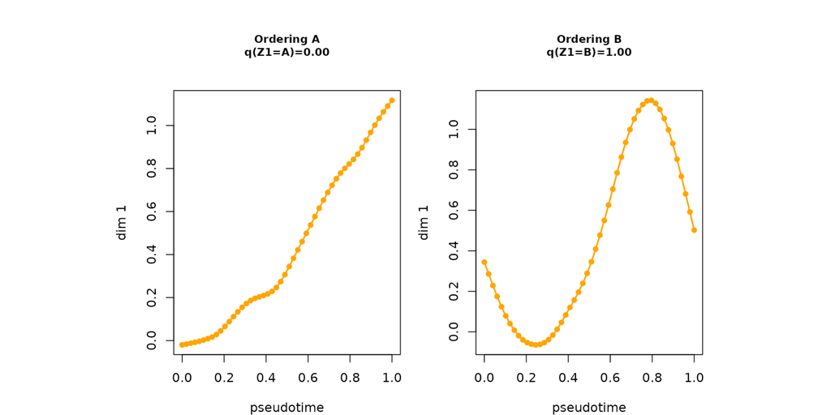

Figure 2. Conditional trajectories under the fixed two-ordering fit, reproduced from the MPCurver 0.3.4 fitness vignette.

The model assigns 27 environments to ordering A and 18 to B by their largest assignment probability. Table 1 groups these assignments by environment category; the full vignette reports the underlying probabilities.

Table 1. Environment counts by category and most probable ordering in the vignette fit.

|  | A | B |
| --- | --- | --- |
| carbon source | 5 | 0 |
| drug / chemical | 6 | 2 |
| glucose / batch | 2 | 7 |
| other | 4 | 5 |
| salt stress | 4 | 0 |
| time course | 6 | 4 |

The two inferred mutant-position vectors have correlation **0.857**. Their orderings are related even though the environments divide between them.

## Measurement uncertainty

The vignette also fits models using reported measurement errors as observation standard deviations. Before fitting, it calibrates those errors from a Student-$t_4$ scale to Gaussian scores; the choice of four degrees of freedom is an analysis assumption. Figure 3 shows conditional trajectories after supplying the adjusted standard deviations to the model.

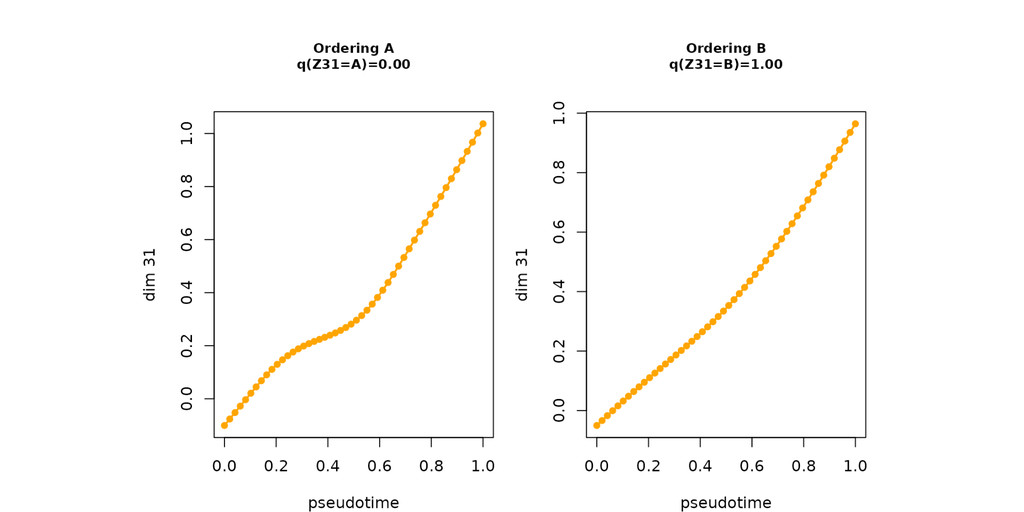

Figure 3. Conditional trajectories with supplied measurement uncertainty, reproduced from the MPCurver 0.3.4 fitness vignette.

## Full analysis

The [MPCurver fitness vignette](https://aguerozz.github.io/MPCurver/articles/fitness.html) provides the preprocessing, fitting calls, environment-level assignment probabilities, and further trajectory plots.